# ECo 602 - Analysis of Environmental Data

Final Project

Liam Waters

Fall 2020

# Introduction

This is an overview of most of the R stats features that were covered in ECo 602/634 and how to use them. This page is a work in progress and will likely be updated again in the future to be more comprehensive and perhaps more visually appealing.

# Functions 1: Data Structure Functions

## `c()`

The function `c()` *combines* or *concatenates* its arguments into a vector (a 1-dimensional data structure consisting of 1 or more elements).

- All of the elements must be of the same *type*.
  - I can’t combine character and numeric types in the same call to `c()`

Here’s two examples using numeric and character data types:

```r
# Create a vector of numbers:
num_vec  = c(1, 4, 8, 9, 13)

# Create a vector of characters:
char_vec = c("a", "fish", "data is cool")
```

I can show the contents of a vector by typing the name of the vector, or using the `print()` function.

```r
# Typing the name of the vector into the console prints the contents
num_vec
```

```
## [1]  1  4  8  9 13
```

```r
# The print() function accomplishes the same task:
print(char_vec)
```

```
## [1] "a"            "fish"         "data is cool"
```

## `data.frame()`

A dataframe stores data in a table of variables. The most common way of getting data into a data frame is through the `read.csv()` function, but if you have data that is in another format the `data.frame()` function converts that data into a data frame. The data columns have to have the same number of attributes and the data within each has to be the same type.

To subset a data frame:

- $columnname if the name is known
- The `str()` function can be used to show the names of the columns

```r
dat_1 = data.frame(
  letters = c("b", "w", "B"),
  numbers_1 = c(34, 6, 123454)
)

dat_1$letters
```

```
## [1] b w B
## Levels: b B w
```

```r
str(dat_1)
```

```
## 'data.frame':    3 obs. of  2 variables:
##  $ letters  : Factor w/ 3 levels "b","B","w": 1 3 2
##  $ numbers_1: num  34 6 123454
```

## `matrix()`

Creates a matrix from the given data. `nrow =` gives the number of rows the data should be divided into. If the data doesn’t divide evenly, values are repeated from the start. `byrow = TRUE` can be used to order the data by row instead of columns (default).

```r
mat_1 = matrix(1:25, nrow = 4)

mat_1
```

```
##      [,1] [,2] [,3] [,4] [,5] [,6] [,7]
## [1,]    1    5    9   13   17   21   25
## [2,]    2    6   10   14   18   22    1
## [3,]    3    7   11   15   19   23    2
## [4,]    4    8   12   16   20   24    3
```

## `length()`

Returns the legnth of whatever object was defined. Works on basically all types of values though typically most useful for vectors.

```r
num_vec
```

```
## [1]  1  4  8  9 13
```

```r
length(num_vec)
```

```
## [1] 5
```

## `nrow()`

Returns the number of rows present in an object.

```r
nrow(dat_1)
```

```
## [1] 3
```

## `ncol()`

Returns the number of columns present in an object.

```r
ncol(dat_1)
```

```
## [1] 2
```

## `dim()`

Returns the dimensions of an object. The first number is the number of rows and the second number is the number of columns.

```r
dim(mat_1)
```

```
## [1] 4 7
```

# Functions 2: Numerical Data Exploration

## `summary()`

Summarizes the object and displays the quantiles if applicable.

```r
summary(dat_1)
```

```
##  letters   numbers_1
##  b:1     Min.   :     6
##  B:1     1st Qu.:    20
##  w:1     Median :    34
##          Mean   : 41165
##          3rd Qu.: 61744
##          Max.   :123454
```

## `mean()`

Returns the mean of a numerical object.

```r
mean(num_vec)
```

```
## [1] 7
```

## `sd()`

Returns the standard deviation of a numerical object.

```r
sd(num_vec)
```

```
## [1] 4.636809
```

# Functions 3: Graphical Data Exploration

## `par()`

`par()` is used to set graphical parameters. For this class `par()` was always used in conjunction with the argument `mfrow =` and a `c()` vector to display multiple charts on a single image.

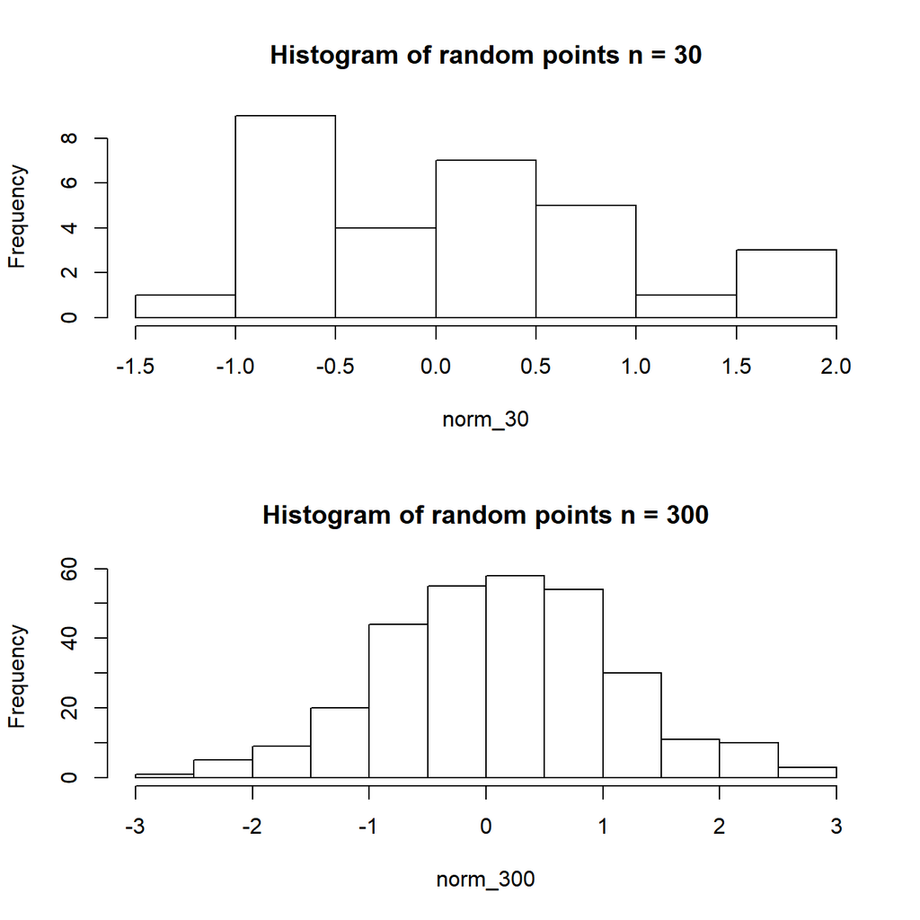

```r
#creating the data for the top histogram
n = 30
norm_30 = rnorm(n)

#creating the data for the bottom histogram
n = 300
norm_300 = rnorm(n)


par(mfrow = c(2,1)) #the first number is rows and the second number is columns

hist(norm_30, main = "Histogram of random points n = 30")
hist(norm_300, main = "Histogram of random points n = 300")
```

## `plot()`

Used to create scatterplots. There are lots of arguments to customize the output, some of which are shown here.

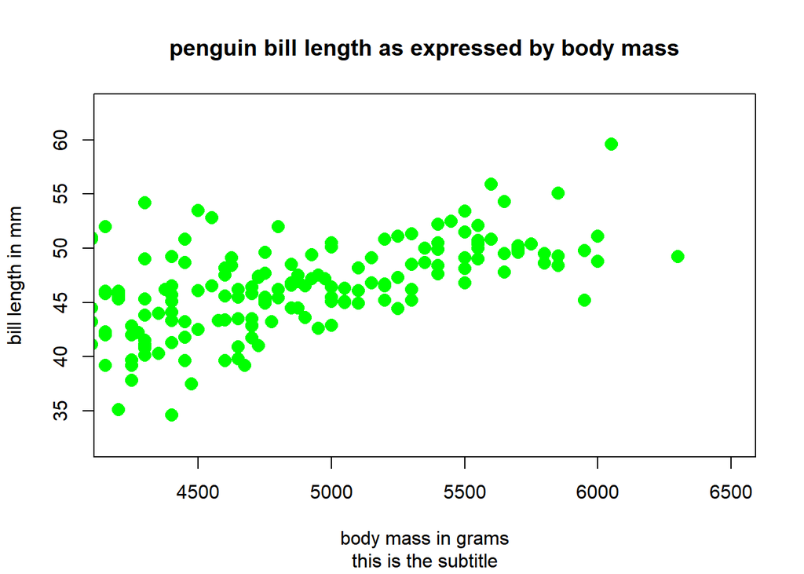

```r
#to load a package, use `require()`
require(palmerpenguins)

#formula notation uses the `~`

plot(bill_length_mm ~ body_mass_g, data = penguins,
     main = "penguin bill length as expressed by body mass",
     sub = "this is the subtitle",
     xlab = "body mass in grams",
     ylab = "bill length in mm",
     xlim = c(4200, 6500),
     ylim = c(32, 63),
     cex = 1.5,
     pch = 16,
     col = "green"
)
```

## `hist()`

Used to create histograms. Similar customization arguments as `plot()`. One new one is `breaks =` which which can be used to set the width of each bar, or column, in the histogram. It can take the form of: - A single number for the the number of bars (but R treats this as mearly a suggestion and will ignore you if it thinks that will be ugly for some reason) - A `c()` giving the breakpoints between bars (which R will not ignore)

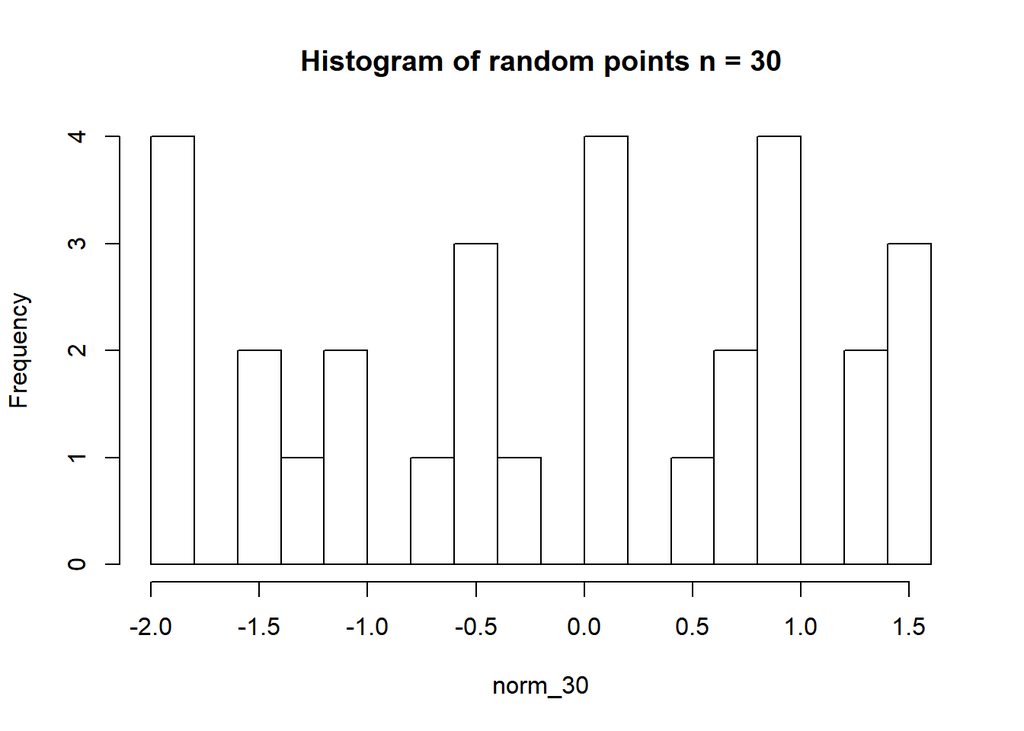

```r
#creating the data for the histogram
n = 30
norm_30 = rnorm(n)

#example 1, with breaks = a single numeric suggestion
hist(norm_30, main = "Histogram of random points n = 30", breaks = 17)
```

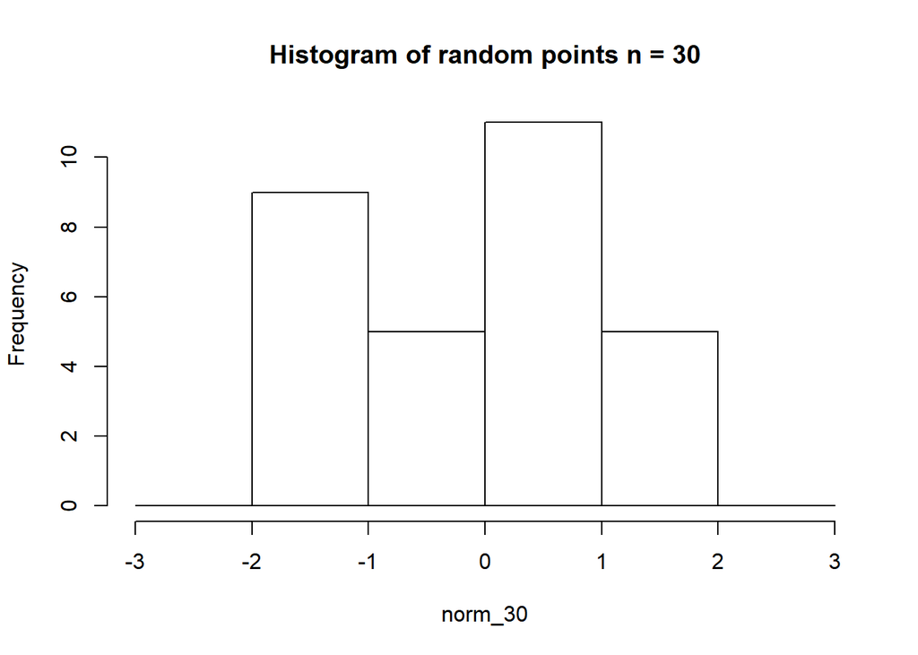

```r
#example 2, with breaks = a specific vector
hist(norm_30, main = "Histogram of random points n = 30", breaks = c(-3, -2, -1, 0, 1, 2, 3))
```

## `boxplot()`

Used to create a box-and-whisker plot of the data. You must include two examples: a simple boxplot (i.e. one box) and a conditional boxplot (i.e. a single plot that has multiple boxes, conditioned on a categorical variable).

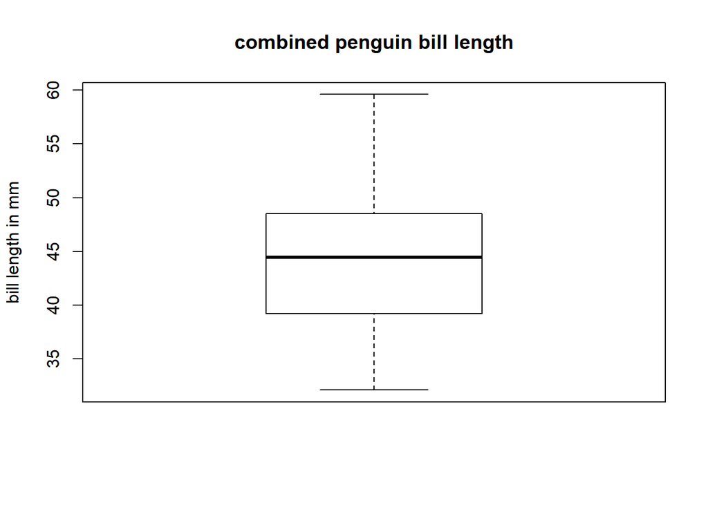

```r
#to load a package, use `require()`
require(palmerpenguins)

#simple boxplot
boxplot(penguins$bill_length_mm, main = "combined penguin bill length", ylab = "bill length in mm")
```

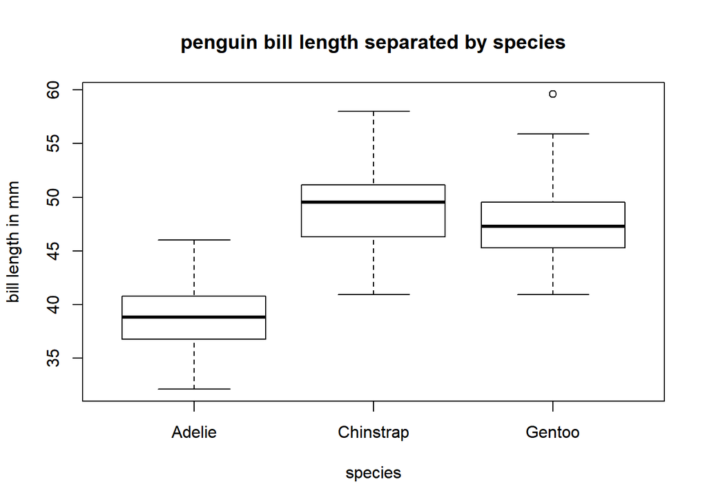

```r
#conditional boxplot that separates the bill length by the species of penguin
boxplot(
  bill_length_mm ~ species, data = penguins,
  main = "penguin bill length separated by species",
  ylab = "bill length in mm"
)
```